# Kate’s Free Week at Camp: DataCamp, Part 2 Intermediate R | Relational Operators

# Table of Contents

1. Equality
2. Greater and less than
3. Compare vectors & matrices
4. Logical Operators
5. Reverse the result: !
6. Conditional Statements
7. While Loop
8. For Loop
9. Functions
10. Writing Your own Function
11. R packages
12. List Apply lapply
13. sapply
14. vapply
15. Useful Functions
16. Regular Expressions
17. Date Time Objects

# 1. Equality

The most basic form of comparison is equality. Let’s briefly recap its syntax. The following statements all evaluate to TRUE.

Example:

```r
3 == (2 + 1)
"intermediate" != "r"
TRUE != FALSE
"Rchitect" != "rchitect"
```

Notice from the last expression that R is case sensitive: “R” is not equal to “r”.

## 1.1 Instructions

```r
## Instructions
# In the editor on the right, write R code to see if TRUE equals FALSE.
# Likewise, check if -6 * 14 is not equal to 17 - 101.
# Next up: comparison of character strings. Ask R whether the strings "useR" and "user" are equal.
# Finally, find out what happens if you compare logicals to numerics: are TRUE and 1 equal?
```

## 1.1a User Input

```r
# Comparison of logicals
TRUE = FALSE
TRUE != FALSE

# Comparison of numerics
(-6 * 14)
(17 - 101)
(-6 * 14) != (17 - 101)
(-6 * 14) = (17 - 101)

# Comparison of character strings
"useR" = "user"

# # Console Results
# > # Compare a logical with a numeric
# > TRUE = 1
# Error: invalid (do_set) left-hand side to assignment
# > # Comparison of logicals
# > TRUE = FALSE
# Error: invalid (do_set) left-hand side to assignment
# > TRUE != FALSE
# [1] TRUE
# >
# > # Comparison of numerics
# > (-6 * 14)
# [1] -84
# > (17 - 101)
# [1] -84
# > (-6 * 14) != (17 - 101)
# [1] FALSE
# > (-6 * 14) = (17 - 101)
# Error: target of assignment expands to non-language object
# >
# > # Comparison of character strings
# > "useR" = "user"
# >
# > # Compare a logical with a numeric
# > TRUE = 1
# Error: invalid (do_set) left-hand side to assignment
```

## 1.1b Final Solution

```r
# Comparison of logicals
TRUE == FALSE

# Comparison of numerics
-6 * 14 != 17 - 101

# Comparison of character strings
"useR" == "user"

# Compare a logical with a numeric
TRUE == 1
```

Note the use of the double equal sign

Since TRUE coerces to 1 under the hood, TRUE == 1 evaluates to TRUE. Make sure not to mix up == (comparison) and = (assignment), == is what need to check the equality of R objects.

# 2. Greater and less than

less than and greater than operators: < and >. You can also add an equal sign to express less than or equal to or greater than or equal to, respectively. Have a look at the following R expressions, that all evaluate to FALSE:

```r
(1 + 2) > 4
"dog" < "Cats"
TRUE <= FALSE
```

R determines the greater than relationship based on alphabetical order.

TRUE is treated as 1 for arithmetic, and FALSE is treated as 0. Therefore, FALSE < TRUE is TRUE.

# 3. Compare vectors & Compare matrices

R’s relational operators also work on vectors.

R’s ability to deal with different data structures for comparisons does not stop at vectors. Matrices and relational operators also work together seamlessly

# 4. Logical Operators

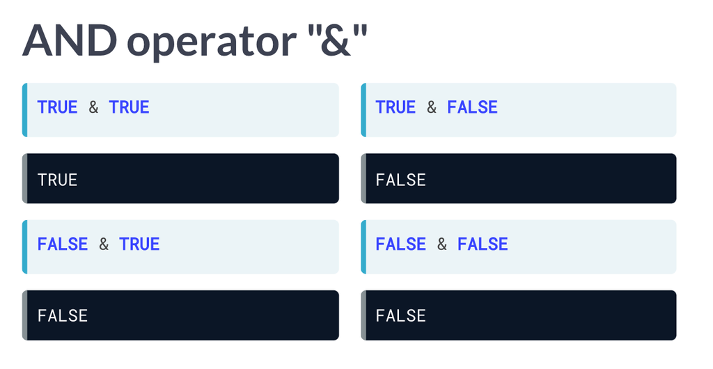

Figure 1 of the “And” Operator

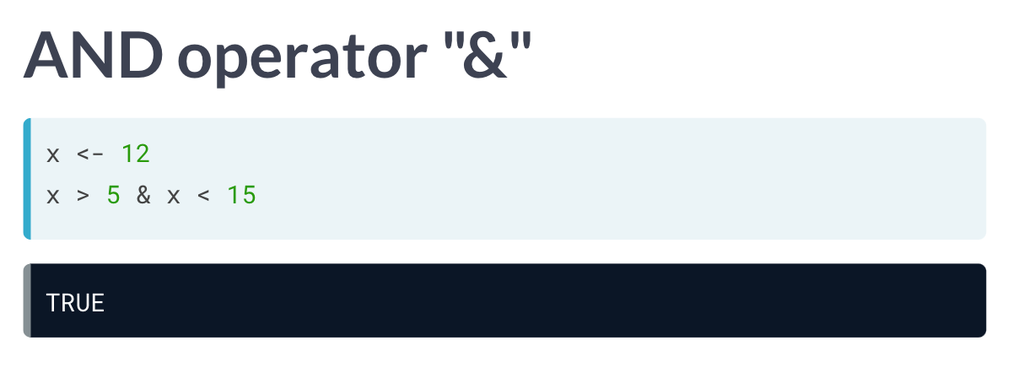

Figure 2 of the “And” Operator

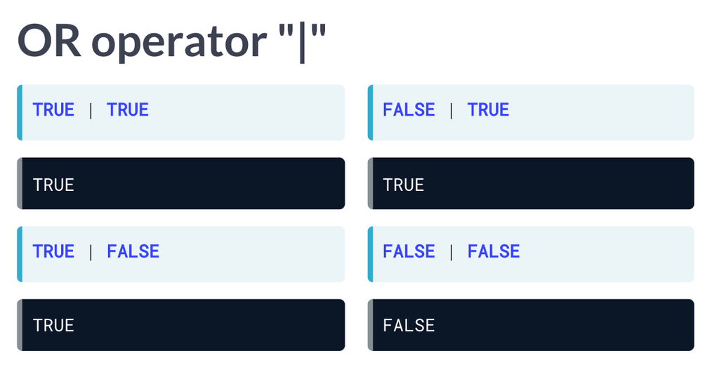

Figure 1 of the “OR” Operator

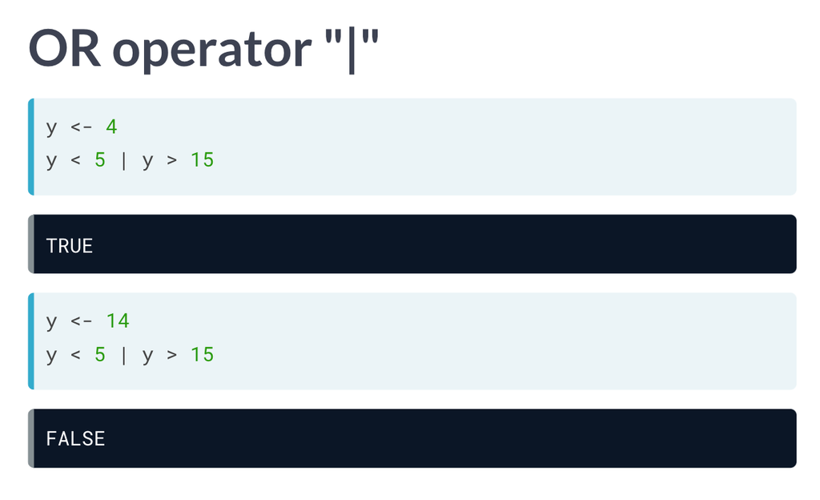

Figure 2 of the “OR” Operator

When the abersand is used twice for some reason it only reads the first element

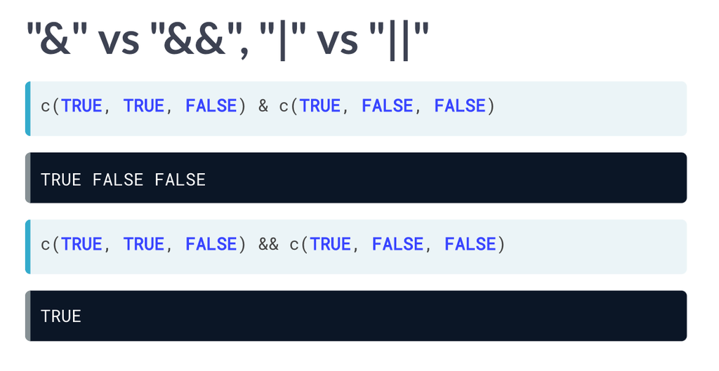

Figure 3 of the “And” Operator

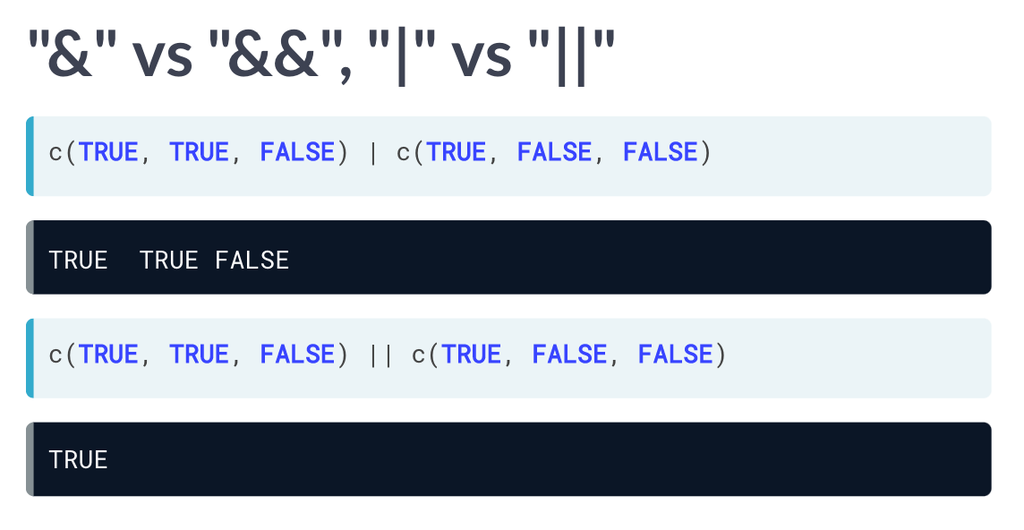

Figure 3 of the “OR” Operator

## 4.1 & and |

Example

```r
TRUE & TRUE
FALSE | TRUE
5 <= 5 & 2 < 3
3 < 4 | 7 < 6

# Console Results
# > TRUE & TRUE
# [1] TRUE
# > FALSE | TRUE
# [1] TRUE
# > 5 <= 5 & 2 < 3
# [1] TRUE
# > 3 < 4 | 7 < 6
# [1] TRUE
```

Like relational operators, logical operators work perfectly fine with vectors and matrices.

# 5. Reverse the result: !

On top of the & and | operators, you also learned about the ! operator, which negates a logical value. To refresh your memory, here are some R expressions that use !. They all evaluate to FALSE:

Example

```r
!TRUE
!(5 > 3)
!!FALSE
```

# 6. Conditional Statements

if statement can be on it’s own whereas the else statement needs an if conditional statement

Figures with If, IF Else statements with results

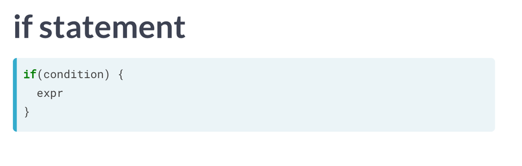

Figure of the “IF” Statement

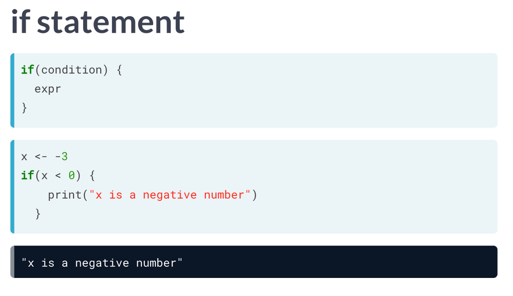

Figure of the “IF” Statement Results

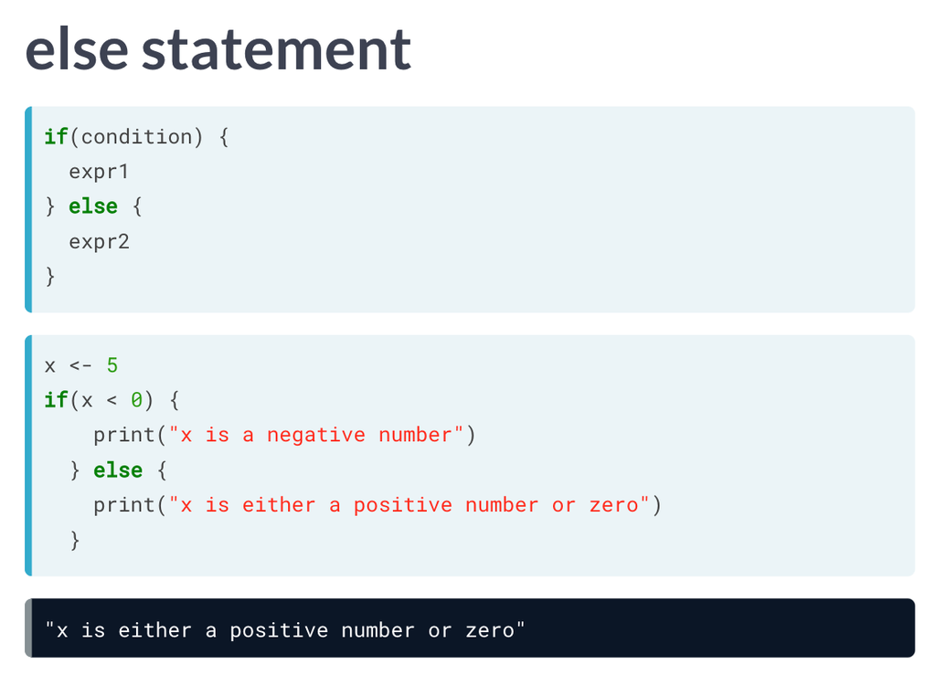

Figure of the “Else” Statement Results

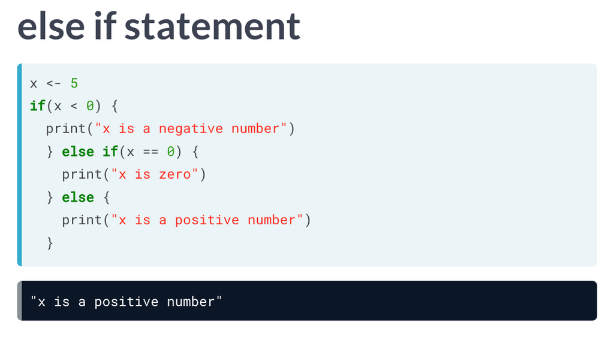

Figure of the “ELSE IF” Statement Results

## 6.1 Condition Statement “IF” Syntax

Review of if statement syntax:

```r
if (condition)
  expr
```

## 6.2 Condition Statement “ELSE” Syntax

You can only use an else statement in combination with an if statement.

The else statement does not require a condition; its corresponding code is simply run if all of the preceding conditions in the control structure are FALSE. else syntax:

```r
if (condition) {
  expr1
} else {
  expr2
}
```

Else Statements examples:

```r
if (number < 10) {
  if (number < 5) {
    result <- "extra small"
  } else {
    result <- "small"
  }
} else if (number < 100) {
  result <- "medium"
} else {
  result <- "large"
}
print(result)
```

Have a look at the following statements:

If number is set to 6, “small” gets printed to the console. CORRECT If number is set to 100, R prints out “medium”. INCORRECT If number is set to 4, “extra small” gets printed out to the console. CORRECT If number is set to 2500, R will generate an error, as result will not be defined. INCORRECT

# 7. While Loop

the while loop does not stop wants to go over and over again

asside- ctr is a counter expression

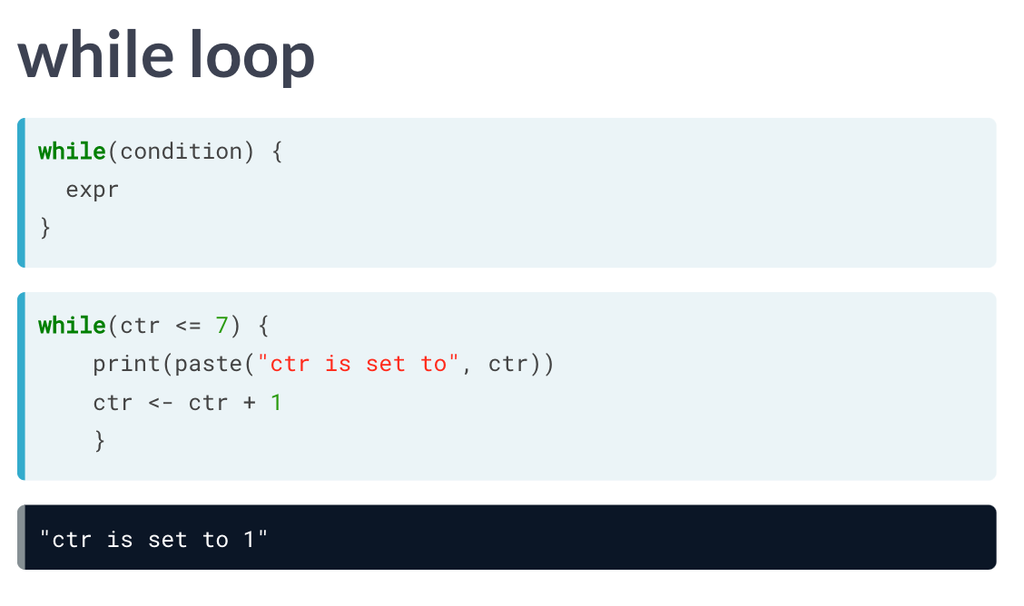

Figure of the “while loop” Statement Results

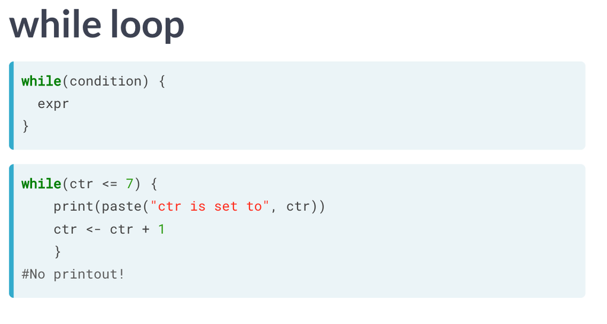

Figure of the “while loop” counting to 7 Statement Results

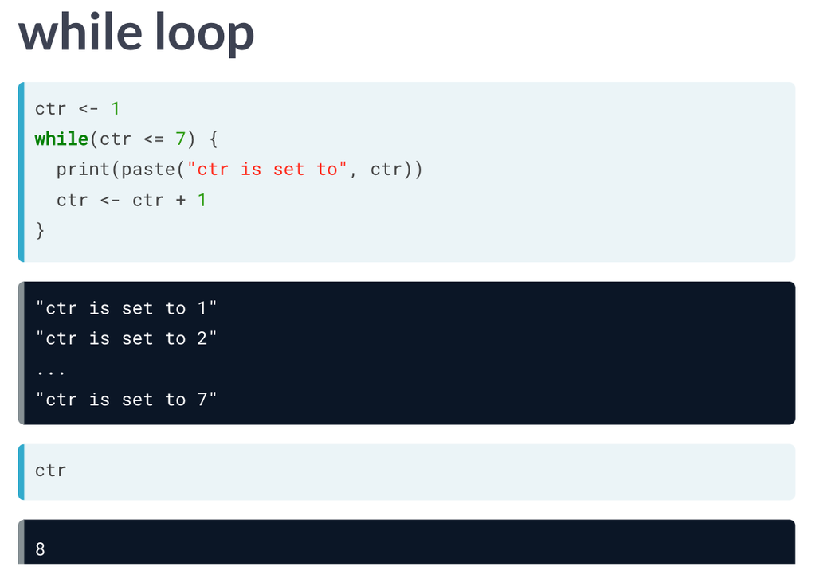

Figure of the “while loop” counting Statement Results

have to give your while loop a place to stop

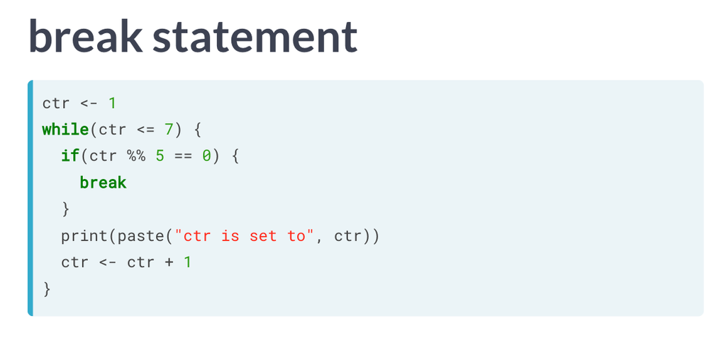

Example of while loop:

```r
# Initialize the speed variable
speed <- 64

# Code the while loop
while (speed > 30) {
  print("Slow down!")
  speed <- speed - 7
}

# Print out the speed variable
speed
```

Example of giving a break statement for the loop:

```r
# Initialize the speed variable
speed <- 88

while (speed > 30) {
  print(paste("Your speed is", speed))

  # Break the while loop when speed exceeds 80
  if (speed > 80) {
    break
  }

  if (speed > 48) {
    print("Slow down big time!")
    speed <- speed - 11
  } else {
    print("Slow down!")
    speed <- speed - 6
  }
}
```

# 8. For Loop

[figure not shown]

Figure of a “for loop” example

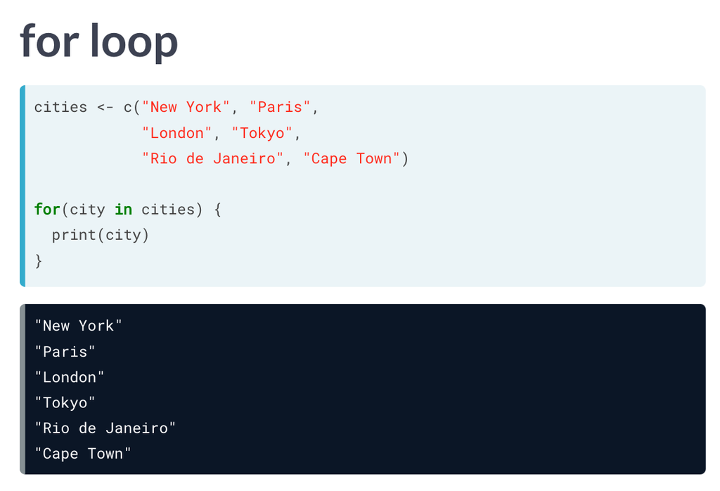

Figure of a “for loop” example with results

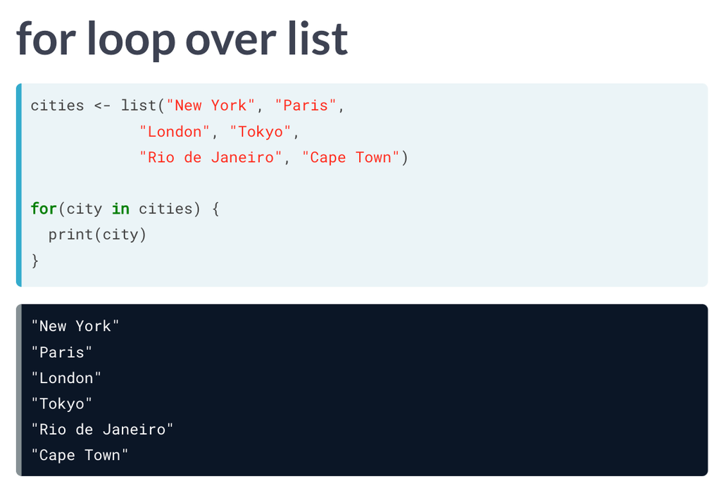

Figure of a “for loop” over a list example

## 8.1 For Loop Control Statements

control statements are still important break next

nchar - Count the Number of Characters (or Bytes or Width)

```r
nchar
```

Description nchar takes a character vector as an argument and returns a vector whose elements contain the sizes of the corresponding elements of x. Internally, it is a generic, for which methods can be defined.

nzchar is a fast way to find out if elements of a character vector are non-empty strings.

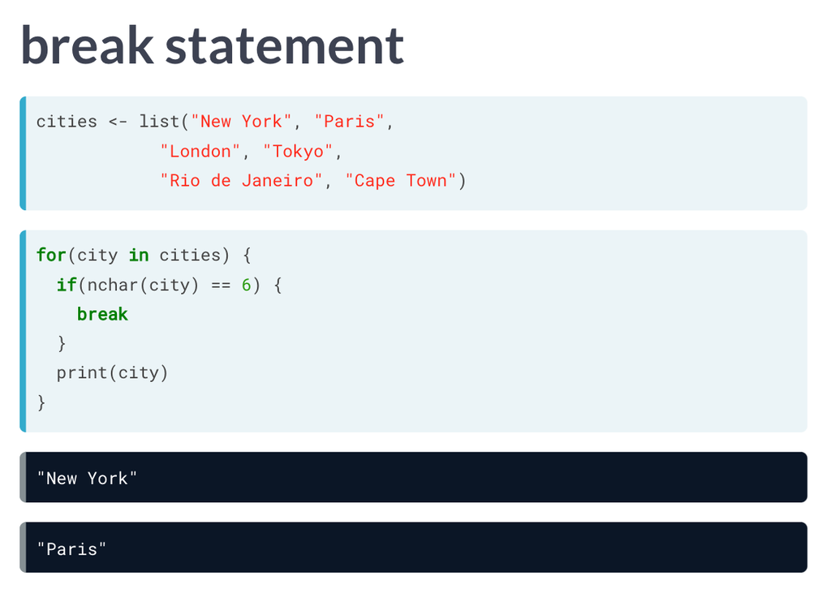

Figure of a “for loop” over a list with a break statement

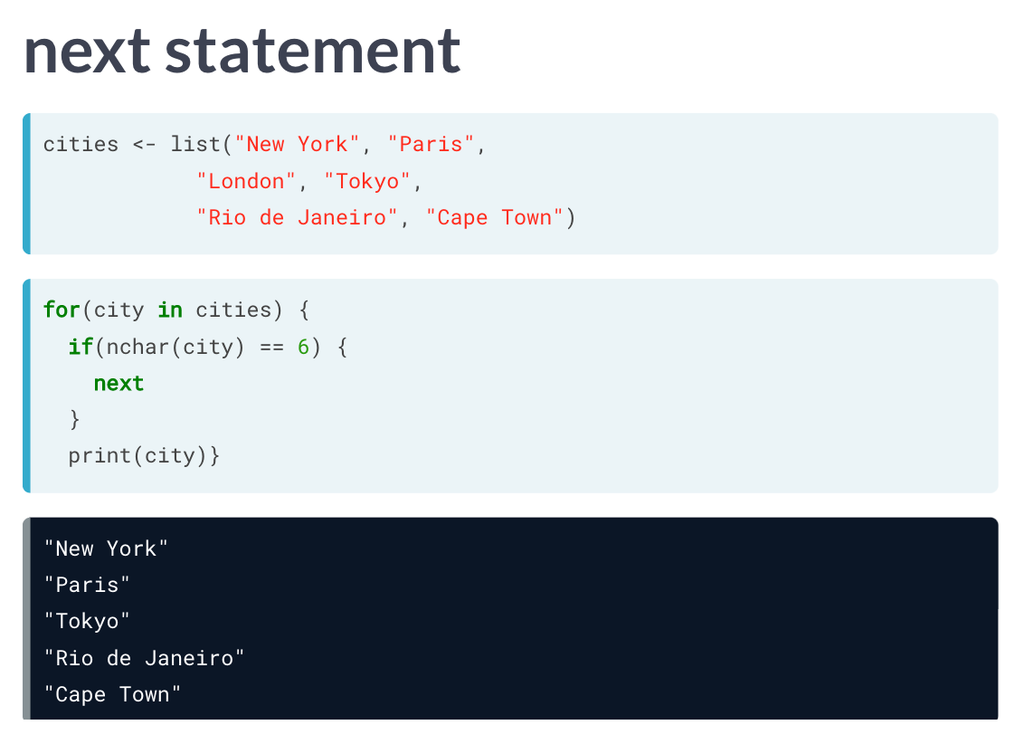

Figure of a “for loop” over a list with a next statement

## 8.2 For Loop “Index”

Can loop based on the length of the items in a list

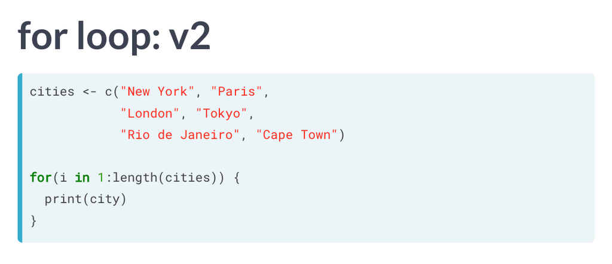

Figure of a “for loop” by the length of the list

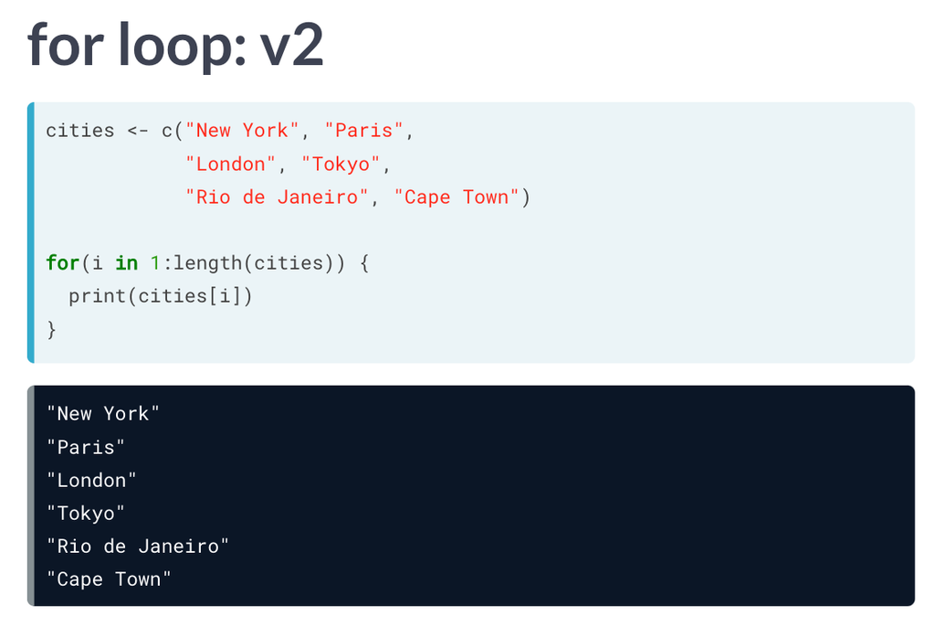

Figure of a “for loop” by the length of the list- index set

You now gain positional information

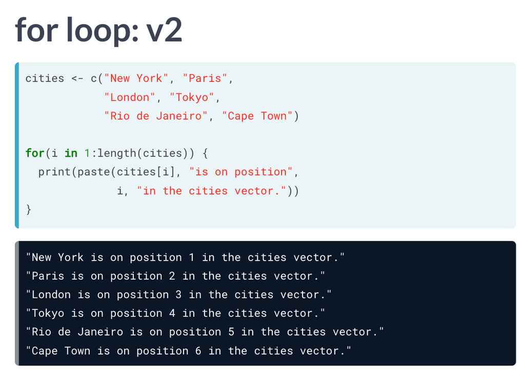

Figure of a “for loop” by the length of the list- index set

## 8.3 Looping over a list

Looping over a list- same as looping over a vector

two different avenues:

```r
primes_list <- list(2, 3, 5, 7, 11, 13)

# loop version 1
for (p in primes_list) {
  print(p)
}

# loop version 2
for (i in 1:length(primes_list)) {
  print(primes_list[[i]])
}
```

Example with NYC data:

```r
# The nyc list is already specified
nyc <- list(pop = 8405837,
            boroughs = c("Manhattan", "Bronx", "Brooklyn", "Queens", "Staten Island"),
            capital = FALSE)

# Loop version 1
for (info in nyc) {
  print(info)
}

# Loop version 2
for (i in 1:length(nyc)) {
  print(nyc[[i]])
}
```

Results

```r
# > # The nyc list is already specified
# > nyc <- list(pop = 8405837,
#               boroughs = c("Manhattan", "Bronx", "Brooklyn", "Queens", "Staten Island"),
#               capital = FALSE)
# >
# > # Loop version 1
# > for (info in nyc) {
#     print(info)
#   }
# [1] 8405837
# [1] "Manhattan"     "Bronx"         "Brooklyn"      "Queens"
# [5] "Staten Island"
# [1] FALSE
# >
# > # Loop version 2
# > for (i in 1:length(nyc)) {
#     print(nyc[[i]])
#   }
# [1] 8405837
# [1] "Manhattan"     "Bronx"         "Brooklyn"      "Queens"
# [5] "Staten Island"
# [1] FALSE
```

## 8.4 Looping over a matrix

Loop over a matrix

Basic set up to loop over a matrix

```r
for (var1 in seq1) {
  for (var2 in seq2) {
    expr
  }
}
```

# 9. Functions

## 9.1 Understanding functions

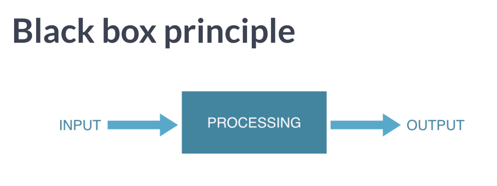

Black Box- principle

example of the black box when using the standard deviation principle

sd()

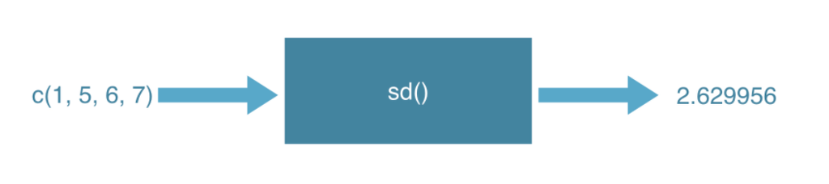

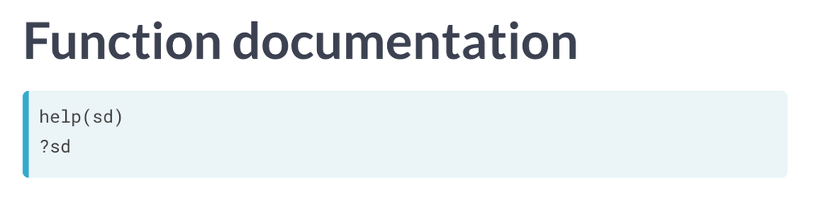

Function - Documentation

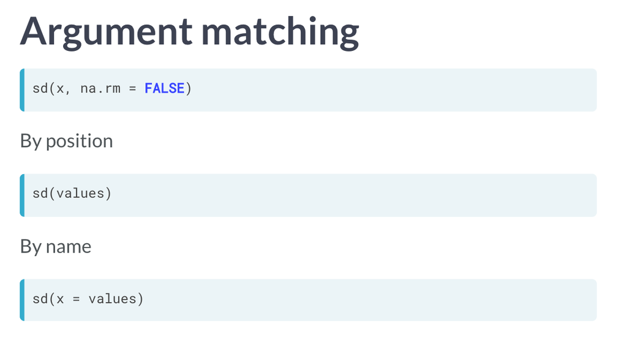

Function - Argument Matching

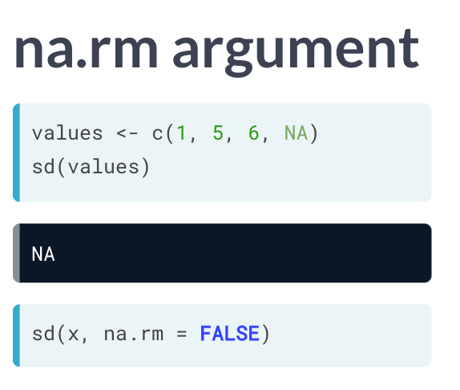

Function - NA values

Rather than use the ? or fn with f1 button you can use the args function to query the syntax of another function

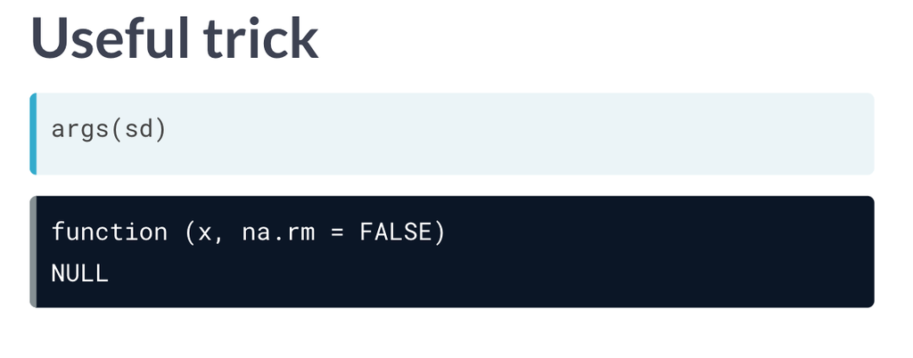

Function - fast way to query a function

# 10. Writing Your own Function

function template:

```r
my_fun <- function(arg1, arg2) {
  body
}
```

Example of random results (throwing dice)

```r
throw_die <- function() {
  number <- sample(1:6, size = 1)
  number
}

throw_die()
```

Example of creating a greeting function, saying hello

```r
# Define the function hello()
hello <- function() {
  print("Hi there!")
  TRUE
}

# Call the function hello()
hello()
```

You can define default argument values in your own R functions

```r
my_fun <- function(arg1, arg2 = val2) {
  body
}
```

# 11. R Packages

Load an R Package There are basically two extremely important functions when it comes down to R packages:

install.packages(), which as you can expect, installs a given package. library() which loads packages, i.e. attaches them to the search list on your R workspace.

To install packages, you need administrator privileges. This means that install.packages() will thus not work in the DataCamp interface. However, almost all CRAN packages are installed on our servers. You can load them with library().

# 12. Lapply

The Usage section shows the following expression:

```r
lapply(X, FUN, ...)
```

```r
multiply <- function(x, factor) {
  x * factor
}
lapply(list(1,2,3), multiply, factor = 3)
```

Apply functions that return NULL

```r
lapply(list(1, "a", TRUE), str)
```

This call actually returns a list, the same size as the input list, containing all NULL values. On the other hand calling

```r
str(TRUE)
```

on its own prints only the structure of the logical to the console, not NULL. That’s because str() uses invisible() behind the scenes, which returns an invisible copy of the return value, NULL in this case. This prevents it from being printed when the result of str() is not assigned.

# 13. sapply

You can use sapply() similar to how you used lapply(). The first argument of sapply() is the list or vector X over which you want to apply a function, FUN. Potential additional arguments to this function are specified afterwards (…):

```r
sapply(X, FUN, ...)
```

Apply a Function over a List or Vector Description lapply returns a list of the same length as X, each element of which is the result of applying FUN to the corresponding element of X.

sapply is a user-friendly version and wrapper of lapply by default returning a vector, matrix or, if simplify = “array”, an array if appropriate, by applying simplify2array(). sapply(x, f, simplify = FALSE, USE.NAMES = FALSE) is the same as lapply(x, f).

# 14. vapply

The function is called vapply(), and it has the following syntax:

vapply(X, FUN, FUN.VALUE, …, USE.NAMES = TRUE)

vapply is similar to sapply, but has a pre-specified type of return value, so it can be safer (and sometimes faster) to use.

# 15. Useful Functions

## 15.1 Mathematical utilities

Have another look at some useful math functions that R features:

abs(): Calculate the absolute value. sum(): Calculate the sum of all the values in a data structure. mean(): Calculate the arithmetic mean. round(): Round the values to 0 decimal places by default. Try out ?round in the console for variations of round() and ways to change the number of digits to round to.

## 15.2 Find the Error

In times of despair, help with functions such as sum() and rev() are a single command away; simply use ?sum and ?rev in the console.

Example:

```r
# > # Don't edit these two lines
vec1 <- c(1.5, 2.5, 8.4, 3.7, 6.3)
 vec2 <- rev(vec1)
# >
# > # Fix the error
# > mean(abs(vec1), abs(vec2))
# Error: 'trim' must be numeric of length one

## Console Result/Solution
# # Don't edit these two lines
# vec1 <- c(1.5, 2.5, 8.4, 3.7, 6.3)
# vec2 <- rev(vec1)
#
# # Fix the error
# mean(c(abs(vec1), abs(vec2)))
```

## 15.3 Data Utilities

R features a bunch of functions to juggle around with data structures::

seq(): Generate sequences, by specifying the from, to, and by arguments. rep(): Replicate elements of vectors and lists. sort(): Sort a vector in ascending order. Works on numerics, but also on character strings and logicals. rev(): Reverse the elements in a data structures for which reversal is defined. str(): Display the structure of any R object. append(): Merge vectors or lists. is.*(): Check for the class of an R object. as.*(): Convert an R object from one class to another. unlist(): Flatten (possibly embedded) lists to produce a vector.